# Task 1

## Web scraping and analysis

This Jupyter notebook includes some code to get you started with web scraping. We will use a package called `BeautifulSoup` to collect the data from the web. Once you've collected your data and saved it into a local `.csv` file you should start with your analysis.

### Scraping data from Skytrax

If you visit [https://www.airlinequality.com] you can see that there is a lot of data there. For this task, we are only interested in reviews related to British Airways and the Airline itself.

If you navigate to this link: [https://www.airlinequality.com/airline-reviews/british-airways] you will see this data. Now, we can use `Python` and `BeautifulSoup` to collect all the links to the reviews and then to collect the text data on each of the individual review links.

```python
import requests
from bs4 import BeautifulSoup
import pandas as pd
```

```python
base_url = "https://www.airlinequality.com/airline-reviews/british-airways"
pages = 10
page_size = 100

reviews = []

# for i in range(1, pages + 1):
for i in range(1, pages + 1):

    print(f"Scraping page {i}")

    # Create URL to collect links from paginated data
    url = f"{base_url}/page/{i}/?sortby=post_date%3ADesc&pagesize={page_size}"

    # Collect HTML data from this page
    response = requests.get(url)

    # Parse content
    content = response.content
    parsed_content = BeautifulSoup(content, 'html.parser')
    for para in parsed_content.find_all("div", {"class": "text_content"}):
        reviews.append(para.get_text())

    print(f"   ---> {len(reviews)} total reviews")
```

```
Scraping page 1
   ---> 100 total reviews
Scraping page 2
   ---> 200 total reviews
Scraping page 3
   ---> 300 total reviews
Scraping page 4
   ---> 400 total reviews
Scraping page 5
   ---> 500 total reviews
Scraping page 6
   ---> 600 total reviews
Scraping page 7
   ---> 700 total reviews
Scraping page 8
   ---> 800 total reviews
Scraping page 9
   ---> 900 total reviews
Scraping page 10
   ---> 1000 total reviews
```

```python
df = pd.DataFrame()
df["reviews"] = reviews
df.head()
```

|  | reviews |
| --- | --- |
| 0 | ✅ Trip Verified \| Flew British Airways on BA ... |
| 1 | ✅ Trip Verified \| BA cancelled the flight fro... |
| 2 | ✅ Trip Verified \| I strongly advise everyone t... |
| 3 | ✅ Trip Verified \| My partner and I were on the... |
| 4 | Not Verified \| We had a Premium Economy retur... |

```python
df
```

|  | reviews |
| --- | --- |
| 0 | ✅ Trip Verified \| Flew British Airways on BA ... |
| 1 | ✅ Trip Verified \| BA cancelled the flight fro... |
| 2 | ✅ Trip Verified \| I strongly advise everyone t... |
| 3 | ✅ Trip Verified \| My partner and I were on the... |
| 4 | Not Verified \| We had a Premium Economy retur... |
| ... | ... |
| 995 | ✅ Trip Verified \| Boston to London Heathrow, ... |
| 996 | ✅ Trip Verified \| London to Cape Town in Firs... |
| 997 | ✅ Trip Verified \| This review is specifically... |
| 998 | ✅ Trip Verified \| London to Aberdeen. Before ... |
| 999 | ✅ Trip Verified \| Gatwick to Dubrovnik. Overc... |

1000 rows × 1 columns

Congratulations! Now you have your dataset for this task! The loops above collected 1000 reviews by iterating through the paginated pages on the website. However, if you want to collect more data, try increasing the number of pages!

The next thing that you should do is clean this data to remove any unnecessary text from each of the rows. For example, "✅ Trip Verified" can be removed from each row if it exists, as it's not relevant to what we want to investigate.

```python
import re

# Define a function to clean the text
def clean(text):
# Removes all special characters and numericals leaving the alphabets
    text = re.sub('[^A-Za-z]+', ' ', str(text))
    return text

# Cleaning the text in the review column
df['Cleaned Reviews'] = df['reviews'].apply(clean)
df.head()
```

[output not shown]

```python
import nltk

"""This punkt tokenizer divides a text into a list of sentences by using an unsupervised algorithm to build a model for abbreviation words,
collocations, and words that start sentences. """

nltk.download('punkt')
from nltk.tokenize import word_tokenize
from nltk import pos_tag
nltk.download('stopwords')
from nltk.corpus import stopwords
nltk.download('wordnet')
from nltk.corpus import wordnet
```

```python
#The nltk.corpus package defines a collection of corpus reader classes, which can be used to access the contents of a diverse set of corpora.


nltk.download('omw-1.4')
nltk.download('averaged_perceptron_tagger')

# POS tagger dictionary
pos_dict = {'J':wordnet.ADJ, 'V':wordnet.VERB, 'N':wordnet.NOUN, 'R':wordnet.ADV}
def token_stop_pos(text):
    tags = pos_tag(word_tokenize(text))
    #print(tags)
    newlist = []
    for word, tag in tags:
        if word.lower() not in set(stopwords.words('english')):
          newlist.append(tuple([word, pos_dict.get(tag[0])]))
          #print(tag[0])
          #print(pos_dict.get(tag[0]))
    return newlist

df['POS tagged'] = df['Cleaned Reviews'].apply(token_stop_pos)
df.head()
```

|  | reviews | Cleaned Reviews | POS tagged |
| --- | --- | --- | --- |
| 0 | Flew British Airways on BA 434 London Heathr... | Flew British Airways on BA London Heathrow to... | [(Flew, n), (British, n), (Airways, n), (BA, n... |
| 1 | BA cancelled the flight from Tokyo to LHR. I... | BA cancelled the flight from Tokyo to LHR I w... | [(BA, n), (cancelled, v), (flight, n), (Tokyo,... |
| 2 | I strongly advise everyone to never fly Briti... | I strongly advise everyone to never fly Briti... | [(strongly, r), (advise, v), (everyone, n), (n... |
| 3 | My partner and I were on the BA2166 return fl... | My partner and I were on the BA return flight... | [(partner, n), (BA, n), (return, n), (flight, ... |
| 4 | We had a Premium Economy return flight Los A... | We had a Premium Economy return flight Los An... | [(Premium, a), (Economy, n), (return, n), (fli... |

```python
from nltk.stem import WordNetLemmatizer
wordnet_lemmatizer = WordNetLemmatizer()
def lemmatize(pos_data):
    lemma_rew = " "
    for word, pos in pos_data:
     if not pos:
        lemma = word
        lemma_rew = lemma_rew + " " + lemma
     else:
        lemma = wordnet_lemmatizer.lemmatize(word, pos=pos)
        lemma_rew = lemma_rew + " " + lemma
    return lemma_rew

df['Lemma'] = df['POS tagged'].apply(lemmatize)
df.head()
```

|  | reviews | Cleaned Reviews | POS tagged | Lemma |
| --- | --- | --- | --- | --- |
| 0 | Flew British Airways on BA 434 London Heathr... | Flew British Airways on BA London Heathrow to... | [(Flew, n), (British, n), (Airways, n), (BA, n... | Flew British Airways BA London Heathrow Amst... |
| 1 | BA cancelled the flight from Tokyo to LHR. I... | BA cancelled the flight from Tokyo to LHR I w... | [(BA, n), (cancelled, v), (flight, n), (Tokyo,... | BA cancel flight Tokyo LHR book next day fli... |
| 2 | I strongly advise everyone to never fly Briti... | I strongly advise everyone to never fly Briti... | [(strongly, r), (advise, v), (everyone, n), (n... | strongly advise everyone never fly British A... |
| 3 | My partner and I were on the BA2166 return fl... | My partner and I were on the BA return flight... | [(partner, n), (BA, n), (return, n), (flight, ... | partner BA return flight Tampa Gatwick excit... |
| 4 | We had a Premium Economy return flight Los A... | We had a Premium Economy return flight Los An... | [(Premium, a), (Economy, n), (return, n), (fli... | Premium Economy return flight Los Angeles Lo... |

```python
df[['reviews','Lemma']]
```

|  | reviews | Lemma |
| --- | --- | --- |
| 0 | Flew British Airways on BA 434 London Heathr... | Flew British Airways BA London Heathrow Amst... |
| 1 | BA cancelled the flight from Tokyo to LHR. I... | BA cancel flight Tokyo LHR book next day fli... |
| 2 | I strongly advise everyone to never fly Briti... | strongly advise everyone never fly British A... |
| 3 | My partner and I were on the BA2166 return fl... | partner BA return flight Tampa Gatwick excit... |
| 4 | We had a Premium Economy return flight Los A... | Premium Economy return flight Los Angeles Lo... |
| ... | ... | ... |
| 995 | Boston to London Heathrow, was excited to ex... | Boston London Heathrow excite experience fir... |
| 996 | London to Cape Town in First and our first t... | London Cape Town First first taste new soft ... |
| 997 | This review is specifically aimed at the exc... | review specifically aim excellent cabin crew... |
| 998 | London to Aberdeen. Before boarding the flig... | London Aberdeen board flight force check bag... |
| 999 | Gatwick to Dubrovnik. Overcrowded lounges, b... | Gatwick Dubrovnik Overcrowded lounge busines... |

1000 rows × 2 columns

```python
!pip install vaderSentiment
```

[output not shown]

```python
from vaderSentiment.vaderSentiment import SentimentIntensityAnalyzer
analyzer = SentimentIntensityAnalyzer()


# function to calculate vader sentiment
def vadersentimentanalysis(review):
    vs = analyzer.polarity_scores(review)
    return vs['compound']

df['Sentiment'] = df['Lemma'].apply(vadersentimentanalysis)

# function to analyse
def vader_analysis(compound):
    if compound >= 0.5:
        return 'Positive'
    elif compound < 0 :
        return 'Negative'
    else:
        return 'Neutral'
df['Analysis'] = df['Sentiment'].apply(vader_analysis)
df.head()
```

|  | reviews | Cleaned Reviews | POS tagged | Lemma | Sentiment | Analysis |
| --- | --- | --- | --- | --- | --- | --- |
| 0 | Flew British Airways on BA 434 London Heathr... | Flew British Airways on BA London Heathrow to... | [(Flew, n), (British, n), (Airways, n), (BA, n... | Flew British Airways BA London Heathrow Amst... | 0.8550 | Positive |
| 1 | BA cancelled the flight from Tokyo to LHR. I... | BA cancelled the flight from Tokyo to LHR I w... | [(BA, n), (cancelled, v), (flight, n), (Tokyo,... | BA cancel flight Tokyo LHR book next day fli... | -0.7090 | Negative |
| 2 | I strongly advise everyone to never fly Briti... | I strongly advise everyone to never fly Briti... | [(strongly, r), (advise, v), (everyone, n), (n... | strongly advise everyone never fly British A... | 0.9450 | Positive |
| 3 | My partner and I were on the BA2166 return fl... | My partner and I were on the BA return flight... | [(partner, n), (BA, n), (return, n), (flight, ... | partner BA return flight Tampa Gatwick excit... | 0.8107 | Positive |
| 4 | We had a Premium Economy return flight Los A... | We had a Premium Economy return flight Los An... | [(Premium, a), (Economy, n), (return, n), (fli... | Premium Economy return flight Los Angeles Lo... | -0.3538 | Negative |

```python
vader_counts = df['Analysis'].value_counts()
vader_counts
```

```
Positive    473
Negative    417
Neutral     110
Name: Analysis, dtype: int64
```

```
 [Text(0.09319348883631644, 1.0960451512773166, 'Positive'),
 [Text(0.050832812092536234, 0.5978428097876272, '47.3%'),
```

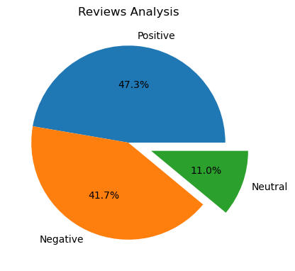

```python
import matplotlib.pyplot as plt
%matplotlib inline
plt.figure(figsize=(15,7))

plt.subplot(1,3,2)
plt.title("Reviews Analysis")
plt.pie(vader_counts.values, labels = vader_counts.index, explode = (0, 0, 0.25), autopct='%1.1f%%', shadow=False)
```

```python
df.to_csv("BA_reviews.csv")
```

```python
!pip install wordcloud
```

[output not shown]

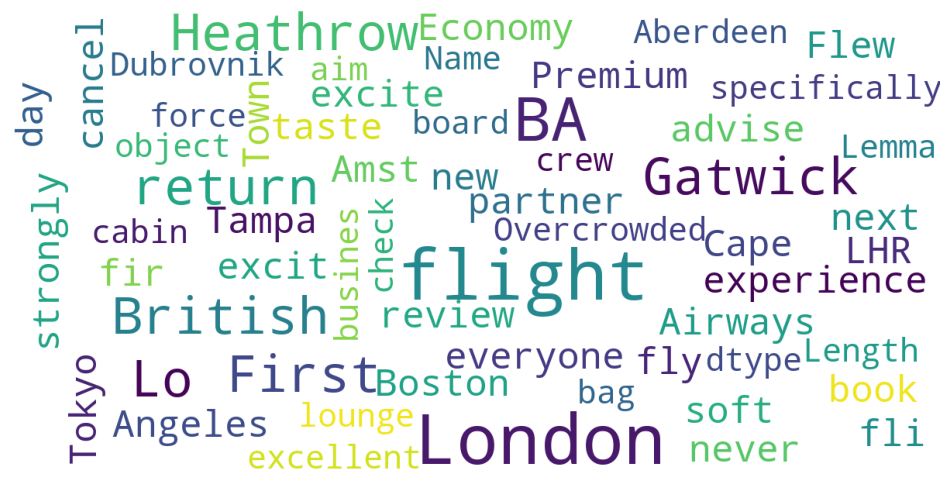

```python
from wordcloud import WordCloud, STOPWORDS
stopwords = set(STOPWORDS)

def show_wordcloud(data):
    wordcloud = WordCloud(
        background_color='white',
        stopwords=stopwords,
        max_words=100,
        max_font_size=30,
        scale=3,
        random_state=1)

    wordcloud=wordcloud.generate(str(data))

    fig = plt.figure(1, figsize=(12, 12))
    plt.axis('off')

    plt.imshow(wordcloud)
    plt.show()

show_wordcloud(df.Lemma)
```